# Unsupervised Machine Learning techniques for market segmentation

Miriam Cardozo

March 2023

## Introducción

Market segmentation is the process of dividing a larger market into smaller groups of consumers who have similar needs, characteristics, or behaviors. This allows companies to target specific groups of consumers with tailored marketing messages and product offerings.

Machine learning algorithms can be useful in the process of market segmentation by analyzing large amounts of data to identify patterns and clusters of consumers with similar demographic and geographic characteristics or behaviors. This can help companies more accurately and efficiently identify and target specific market segments and optimize their marketing, advertising, and sales efforts.

### **About the dataset**

The dataset for an Indian store includes 10000 observations and 5 variables:

| Variable | Description |
| --- | --- |
| *reps* | Representatives who are involved in the promotion and sale of the products in their respective region. |
| *products* | The 12 brands of products promoted by the company. |
| *qty* | The quantity of products sold in units per transaction. |
| *revenue* | The revenue generated for each transaction. |
| *region* | Indicates the region in India where the transaction took place, with four regions: East, North, South, and West India. |

Seetharam Indurti (2019) [Dataset available at: Kaggle)

### **Objective**

The aim of this project is to obtain the segmentation of products based on the revenue generated in different regions in order to understand the market trends. The segmentation will help the company to devise marketing strategies and promotional schemes to position the right product according to the preference of the consumers in any given segment.

## 1. Importing data (.csv)

```r
datos <-read.csv("store.csv", header=T, sep = ",", dec=".")
```

```r
##Load libraries
library(dplyr)
library(ggplot2)
library(caret)
library(tibble)
library(tidyr)
library(factoextra)
library(forcats)
library(knitr)
```

## 2. Exploratory Data Analysis (EDA)

```r
###2.a. Structure of data####
head(datos, n=10)
```

```
##      reps product qty revenue region
## 1  Chitra  Galaxy   2  155.10   West
## 2   Vijay     Jet   2   39.30  North
## 3    Mala  Beacon   3   74.25   West
## 4   Suman   Alpen   3  100.98  North
## 5  Rachna   Orbit   2   44.98  North
## 6    Aash Trident   1   29.25   East
## 7   Chand    Mars   3   68.39  North
## 8   Suraj   Orbit   2   45.44   West
## 9  Rachna   Milka   1   22.38  North
## 10   Bala  Almond   2   49.25   West
```

```r
str(datos)
```

```
## 'data.frame':    10000 obs. of  5 variables:
##  $ reps   : chr  "Chitra" "Vijay" "Mala" "Suman" ...
##  $ product: chr  "Galaxy" "Jet" "Beacon" "Alpen" ...
##  $ qty    : int  2 2 3 3 2 1 3 2 1 2 ...
##  $ revenue: num  155.1 39.3 74.2 101 45 ...
##  $ region : chr  "West" "North" "West" "North" ...
```

```r
dim(datos)
```

```
## [1] 10000     5
```

```r
#summary statistics
summary(datos)
```

```
##      reps             product               qty            revenue
##  Length:10000       Length:10000       Min.   : 1.000   Min.   :  18.43
##  Class :character   Class :character   1st Qu.: 2.000   1st Qu.:  39.30
##  Mode  :character   Mode  :character   Median : 2.000   Median :  58.42
##                                        Mean   : 3.387   Mean   :  90.57
##                                        3rd Qu.: 3.000   3rd Qu.:  75.00
##                                        Max.   :25.000   Max.   :1998.75
##     region
##  Length:10000
##  Class :character
##  Mode  :character
##
##
##
```

```r
#categorical variables levels
library(forcats)
fct_count(datos$product) #12 different products
```

```
## # A tibble: 12 × 2
##    f           n
##    <fct>   <int>
##  1 Almond   1015
##  2 Alpen    1588
##  3 Beacon    651
##  4 Galaxy    342
##  5 Halls     307
##  6 Jet      1274
##  7 Mars      638
##  8 Milka    1294
##  9 Orbit    1255
## 10 Prince    325
## 11 Star      652
## 12 Trident   659
```

```r
fct_count(datos$reps) #72 different reps
```

```
## # A tibble: 72 × 2
##    f           n
##    <fct>   <int>
##  1 Aash      315
##  2 Akila     109
##  3 Alka      116
##  4 Anahit    104
##  5 Ananya    216
##  6 Anusha     82
##  7 Aparna    104
##  8 Bala       97
##  9 Bharath   171
## 10 Bhat       87
## # … with 62 more rows
```

```r
fct_count(datos$region) #4 regions
```

```
## # A tibble: 4 × 2
##   f         n
##   <fct> <int>
## 1 East   1703
## 2 North  3603
## 3 South  1665
## 4 West   3029
```

The dataset contains 10000 transactions of revenues from 12 different products sold by 72 representatives in 4 regions of India (Western, Norther, Souther and Easter India).

```r
# check missing values
any(!complete.cases(datos))
```

```
## [1] FALSE
```

The dataset does not contain missing values.

### Quantitative variables

**Data visualization**

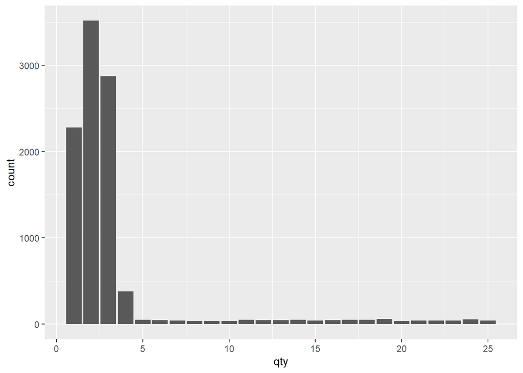

```r
#Histograms
ggplot(datos, aes(x = qty)) + geom_bar()
```

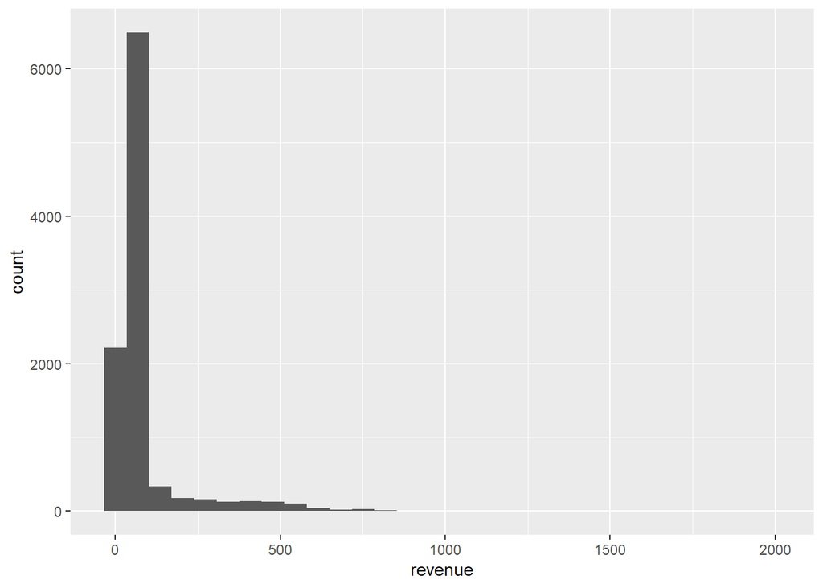

```r
ggplot(datos, aes(x = revenue)) + geom_histogram()
```

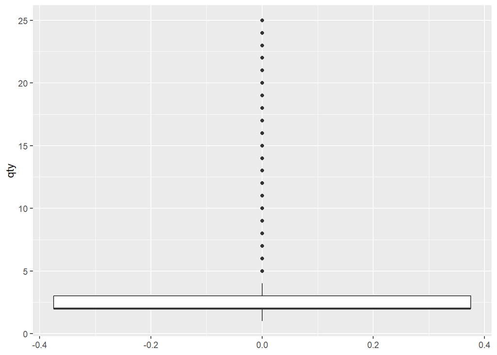

```r
#Boxplot
ggplot(datos, aes(y = qty)) + geom_boxplot()
```

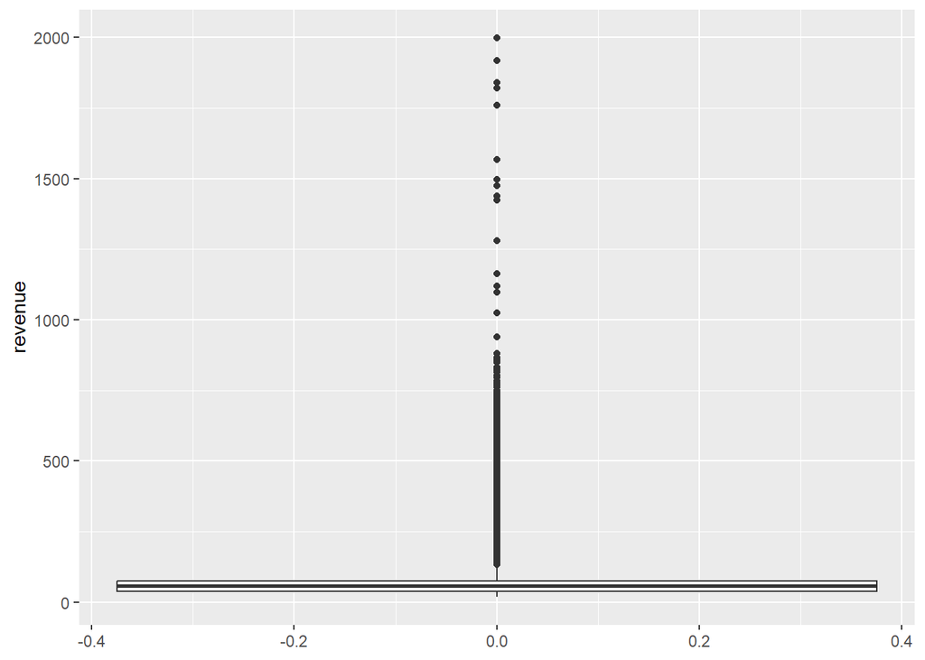

```r
ggplot(datos, aes(y = revenue)) + geom_boxplot()
```

The variables *qty* and *revenue* show outliers in their distribution. However, at first we’ll consider all values in the model since it may contain valuable information of importat revenues.

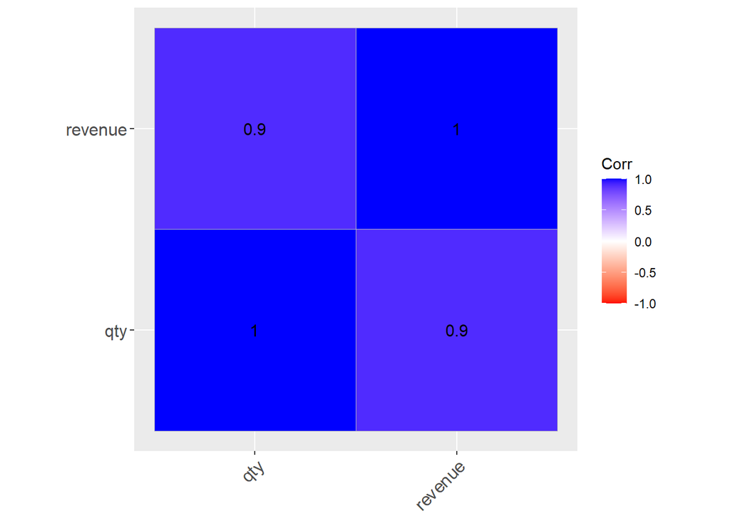

```r
###Check correlation between variables
library(ggcorrplot)
options(repr.plot.width = 6, repr.plot.height = 5)

#Correlogram plot
corr <- round(cor(select_if(datos, is.numeric)), 2)
ggcorrplot(corr, hc.order = T, ggtheme = ggplot2::theme_gray,
           colors = c("red", "white", "blue"), lab = T)
```

As it was expected, the variables *qty* and *revenue* are highly correlated.

**What products are fast moving in terms of the quantity and revenue generated?**

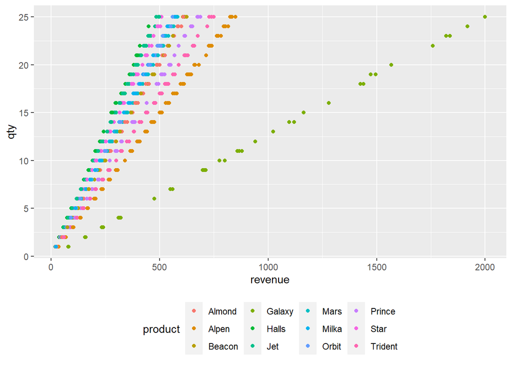

```r
#Scatter plot
options(repr.plot.width = 11, repr.plot.height = 5)

#Qty and revenue by products
scplot1 <- ggplot(datos, aes(revenue, qty, col = product)) +
  geom_point() + theme(legend.position = 'bottom') +
  labs(x='revenue', y ='qty')
print(scplot1)
```

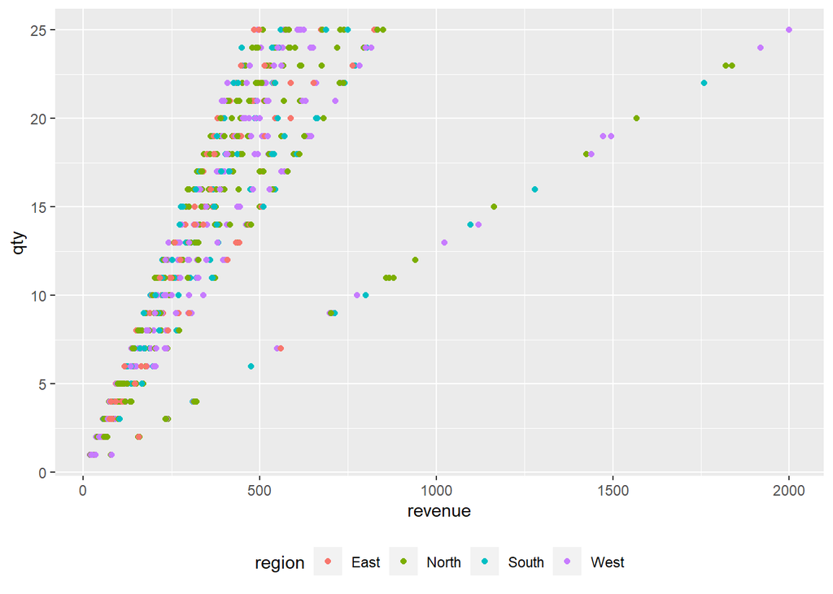

```r
#Qty and revenue by region
scplot2 <- ggplot(datos, aes(revenue, qty, col = region)) +
  geom_point() + theme(legend.position = 'bottom') +
  labs(x='revenue', y ='qty')
print(scplot2)
```

### Categorical variables

**Data visualization**

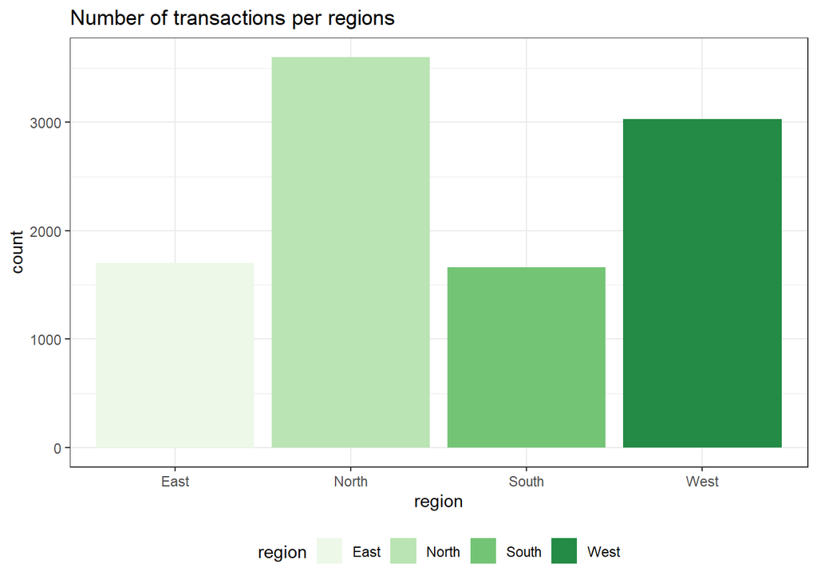

```r
#Transactions per region
ggplot(data = datos, aes(x = region, y = after_stat(count), fill = region)) +
  geom_bar() +
  scale_fill_brewer(palette ="Greens") +
  labs(title = "Number of transactions per regions") +
  theme_bw() +
  theme(legend.position = "bottom")
```

**Are there regional differences in the quantity of items sold and the revenue achieved?**

```r
datos %>%
  group_by(region) %>%
  summarise(Tot_qty= sum(qty),
            Tot_revenue=sum(revenue),
            Tot_transactions= n()) %>%
  kable(caption ="Total transactions per region")
```

Total transactions per region

| region | Tot_qty | Tot_revenue | Tot_transactions |
| --- | --- | --- | --- |
| East | 5614 | 146141.5 | 1703 |
| North | 12174 | 326109.5 | 3603 |
| South | 5908 | 158819.9 | 1665 |
| West | 10178 | 274631.3 | 3029 |

The north (3603) and west (3029) regions double the number of transactions to the east and south regions. Hence the total quantity of sold products and total revenue in this regions are higher too.

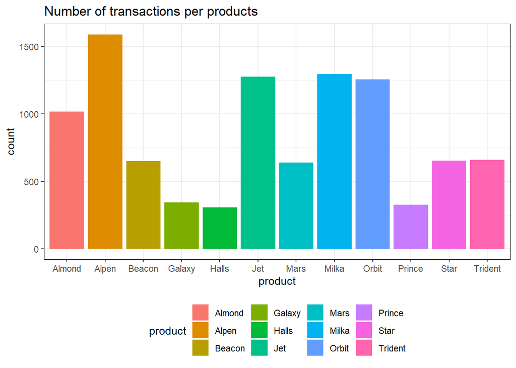

```r
#Products
ggplot(data = datos, aes(x = product, y = after_stat(count), fill = product)) +
  geom_bar() +
  labs(title = "Number of transactions per products") +
  theme_bw() +
  theme(legend.position = "bottom")
```

```r
datos %>%
  group_by(product) %>%
  summarise(tot_qty= sum(qty),
            tot_revenue=sum(revenue),
            tot_transactions= n()) %>%
  arrange(desc(tot_revenue)) %>%
  kable(caption = "Total transactions and revenue per products")
```

Total transactions and revenue per products

| product | tot_qty | tot_revenue | tot_transactions |
| --- | --- | --- | --- |
| Alpen | 5267 | 177152.07 | 1588 |
| Orbit | 4375 | 99284.25 | 1255 |
| Milka | 4153 | 94249.40 | 1294 |
| Galaxy | 1150 | 90919.18 | 342 |
| Jet | 4262 | 84077.56 | 1274 |
| Almond | 3258 | 80581.91 | 1015 |
| Trident | 2436 | 72289.20 | 659 |
| Mars | 2498 | 58109.60 | 638 |
| Beacon | 2152 | 53164.41 | 651 |
| Star | 2101 | 43637.99 | 652 |
| Prince | 1253 | 34025.46 | 325 |
| Halls | 969 | 18211.18 | 307 |

Overall, of the 12 products sold in the 4 regions, Alpen is the best-selling in India with a total revenue of 177152.07 rupies, followed by Orbit, Milka, and Galaxy. Halls generated the lowest revenue.

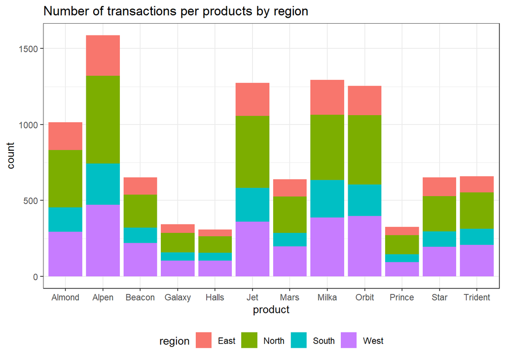

```r
#Products per region
ggplot(data = datos, aes(x = product, y = after_stat(count), fill = region)) +
  geom_bar() +
  labs(title = "Number of transactions per products by region") +
  theme_bw() +
  theme(legend.position = "bottom")
```

**Suppose that the store manager want to identified the more efficient representative in each region in terms of revenue and transactions.**

```r
#One alternative is using pivot tables
library(pivottabler)

pt <- PivotTable$new()
pt$addData(datos)
pt$addRowDataGroups("region")
pt$addRowDataGroups("reps")
pt$defineCalculation(calculationName="Tot_transactions", summariseExpression="n()")
pt$defineCalculation(calculationName="Tot_revenues", summariseExpression="sum(revenue)")
pt$evaluatePivot()

# apply the green style for reps with more than 300 transactions
cells <- pt$findCells(minValue=300, maxValue=1000, includeNull=FALSE, includeNA=FALSE)
pt$setStyling(cells=cells, declarations=list("background-color"="#C6EFCE", "color"="#006100"))

# apply the yellow style for revenues higher than 20000
cells <- pt$findCells(minValue=20000, maxValue=50000, includeNull=FALSE, includeNA=FALSE)
pt$setStyling(cells=cells, declarations=list("background-color"="#FFEB9C", "color"="#9C5700"))

pt$renderPivot()
```

[interactive chart not shown]

The total revenue generated by all the representatives for the company is 9,05,702.21 rupies, covering 12 brands and involving 10,000 transactions in all the 4 regions. However, there is a difference between regions in the efficiency to generate revenue between the reps. In the table above, in green, the most efficient representatives of the 4 regions that reach more than 300 transactions obtaining total revenues higher than 20,000 rupies (yellow) are indicated.

- East region: Aash and Vish
- South region: Seet
- North region: Rachna
- West region: Santosh

  **Suppose that now the store manager want to see the revenue and quantity broken down by the products and region.**

```r
#Sales trends of products per reps
pt2 <- PivotTable$new()
pt2$addData(datos)
pt2$addRowDataGroups("region")
pt2$addColumnDataGroups("product")
pt2$defineCalculation(calculationName="tot_revenue", summariseExpression="sum(revenue)")
pt2$defineCalculation(calculationName="tot_qty", summariseExpression="sum(qty)")
pt2$evaluatePivot()
pt2$renderPivot()
```

[interactive chart not shown]

## 3. Data preprocessing

```r
#Normalizing data
datos_preProces <-preProcess(datos, method = c("scale", "center"))
datos_uns <- predict(datos_preProces,datos)

#One Hot-encoding
datos_uns$reps <- as.factor(datos_uns$reps)
datos_uns$region <- as.factor(datos_uns$region)
datos_uns$product <- as.factor(datos_uns$product)
library(mltools)
library(data.table)
datos_uns <- one_hot(as.data.table(datos_uns))

#Chequeamos preprocesamiento
str(datos_uns)
```

```
## Classes 'data.table' and 'data.frame':   10000 obs. of  90 variables:
##  $ reps_Aash      : int  0 0 0 0 0 1 0 0 0 0 ...
##  $ reps_Akila     : int  0 0 0 0 0 0 0 0 0 0 ...
##  $ reps_Alka      : int  0 0 0 0 0 0 0 0 0 0 ...
##  $ reps_Anahit    : int  0 0 0 0 0 0 0 0 0 0 ...
##  $ reps_Ananya    : int  0 0 0 0 0 0 0 0 0 0 ...
##  $ reps_Anusha    : int  0 0 0 0 0 0 0 0 0 0 ...
##  $ reps_Aparna    : int  0 0 0 0 0 0 0 0 0 0 ...
##  $ reps_Bala      : int  0 0 0 0 0 0 0 0 0 1 ...
##  $ reps_Bharath   : int  0 0 0 0 0 0 0 0 0 0 ...
##  $ reps_Bhat      : int  0 0 0 0 0 0 0 0 0 0 ...
##  $ reps_Chand     : int  0 0 0 0 0 0 1 0 0 0 ...
##  $ reps_Chandra   : int  0 0 0 0 0 0 0 0 0 0 ...
##  $ reps_Chitra    : int  1 0 0 0 0 0 0 0 0 0 ...
##  $ reps_Durga     : int  0 0 0 0 0 0 0 0 0 0 ...
```

[output cut: 77 more lines]

## 4. Asessing Clustering Tendency

Before applying any clustering method on your data, it’s important to evaluate whether the data sets contains meaningful clusters. Because, even if the data is uniformly distributed, the k-means algorithm and hierarchical clustering impose a classification. Since the main problem faced by unsupervised learning methods is the difficulty in validating the results (because there is no response variable available to compare them), this type of analysis can be used to evaluate the validity of clustering analysis.

```r
library(clustertend)
```

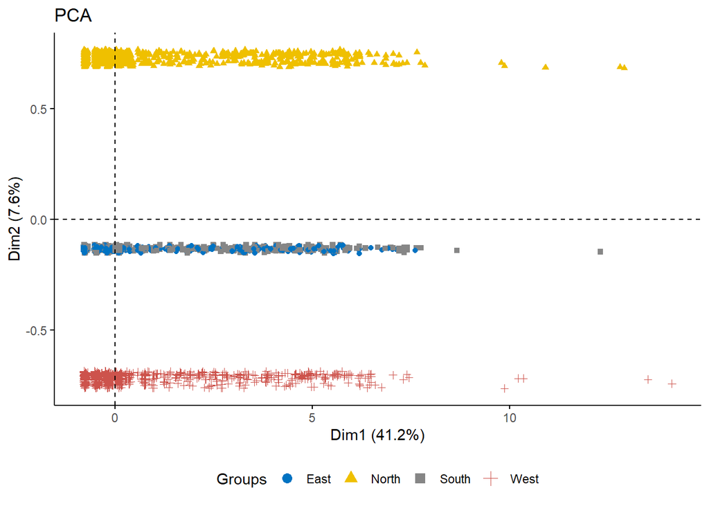

```r
# Plot data set
fviz_pca_ind(prcomp(datos_uns), title = "PCA",
             habillage = datos$region, palette = "jco",
             geom = "point", ggtheme = theme_classic(),
             legend = "bottom")
```

As we can see, the data is not randomly or uniformly distributed.

## 5. Principal Component Analysis (PCA)

Principal Component Analysis belongs to the family of techniques known as unsupervised learning. This method allows to “condense” the information provided by multiple variables into just a few components, to find a linear combination of the original features that capture maximum variance in the dataset.

```r
library(FactoMineR)

#Running a PCA.
store_pca <- PCA(datos_uns, graph = FALSE)
print(store_pca)
```

```
## **Results for the Principal Component Analysis (PCA)**
## The analysis was performed on 10000 individuals, described by 90 variables
## *The results are available in the following objects:
##
##    name               description
## 1  "$eig"             "eigenvalues"
## 2  "$var"             "results for the variables"
## 3  "$var$coord"       "coord. for the variables"
## 4  "$var$cor"         "correlations variables - dimensions"
## 5  "$var$cos2"        "cos2 for the variables"
## 6  "$var$contrib"     "contributions of the variables"
## 7  "$ind"             "results for the individuals"
## 8  "$ind$coord"       "coord. for the individuals"
## 9  "$ind$cos2"        "cos2 for the individuals"
## 10 "$ind$contrib"     "contributions of the individuals"
## 11 "$call"            "summary statistics"
## 12 "$call$centre"     "mean of the variables"
## 13 "$call$ecart.type" "standard error of the variables"
## 14 "$call$row.w"      "weights for the individuals"
## 15 "$call$col.w"      "weights for the variables"
```

```r
#Exploring PCA()
# Getting the summary of the pca
summary(store_pca)
```

```
##
## Call:
## PCA(X = datos_uns, graph = FALSE)
##
##
## Eigenvalues
##                        Dim.1   Dim.2   Dim.3   Dim.4   Dim.5   Dim.6   Dim.7
## Variance               2.520   2.318   2.229   1.962   1.217   1.196   1.183
## % of var.              2.801   2.576   2.477   2.180   1.353   1.329   1.315
## Cumulative % of var.   2.801   5.376   7.853  10.033  11.386  12.715  14.030
##                        Dim.8   Dim.9  Dim.10  Dim.11  Dim.12  Dim.13  Dim.14
## Variance               1.170   1.136   1.134   1.132   1.125   1.105   1.097
## % of var.              1.300   1.262   1.260   1.258   1.250   1.227   1.219
## Cumulative % of var.  15.330  16.593  17.852  19.110  20.360  21.587  22.806
##                       Dim.15  Dim.16  Dim.17  Dim.18  Dim.19  Dim.20  Dim.21
## Variance               1.091   1.031   1.031   1.030   1.030   1.029   1.028
## % of var.              1.213   1.146   1.145   1.144   1.144   1.143   1.142
## Cumulative % of var.  24.019  25.165  26.310  27.454  28.598  29.742  30.884
##                       Dim.22  Dim.23  Dim.24  Dim.25  Dim.26  Dim.27  Dim.28
## Variance               1.025   1.024   1.022   1.020   1.019   1.019   1.018
## % of var.              1.139   1.138   1.136   1.134   1.133   1.132   1.131
## Cumulative % of var.  32.023  33.161  34.296  35.430  36.563  37.695  38.826
##                       Dim.29  Dim.30  Dim.31  Dim.32  Dim.33  Dim.34  Dim.35
## Variance               1.017   1.017   1.016   1.014   1.014   1.012   1.011
## % of var.              1.130   1.130   1.128   1.127   1.127   1.125   1.124
## Cumulative % of var.  39.956  41.086  42.214  43.342  44.468  45.593  46.717
##                       Dim.36  Dim.37  Dim.38  Dim.39  Dim.40  Dim.41  Dim.42
## Variance               1.011   1.011   1.011   1.011   1.011   1.011   1.011
## % of var.              1.124   1.124   1.124   1.124   1.123   1.123   1.123
## Cumulative % of var.  47.840  48.964  50.088  51.211  52.335  53.458  54.581
##                       Dim.43  Dim.44  Dim.45  Dim.46  Dim.47  Dim.48  Dim.49
## Variance               1.011   1.011   1.011   1.011   1.010   1.010   1.010
## % of var.              1.123   1.123   1.123   1.123   1.123   1.123   1.123
## Cumulative % of var.  55.704  56.827  57.950  59.073  60.196  61.319  62.441
##                       Dim.50  Dim.51  Dim.52  Dim.53  Dim.54  Dim.55  Dim.56
## Variance               1.010   1.010   1.010   1.010   1.010   1.010   1.010
## % of var.              1.122   1.122   1.122   1.122   1.122   1.122   1.122
## Cumulative % of var.  63.564  64.686  65.808  66.931  68.053  69.175  70.297
##                       Dim.57  Dim.58  Dim.59  Dim.60  Dim.61  Dim.62  Dim.63
## Variance               1.010   1.010   1.010   1.010   1.010   1.009   1.009
```

[output cut: 51 more lines]

```
## reps_Aparna     | -0.126  0.635  0.016 | -0.049  0.102  0.002 | -0.002  0.000
## reps_Bala       |  0.116  0.533  0.013 | -0.094  0.383  0.009 |  0.001  0.000
## reps_Bharath    |  0.035  0.049  0.001 |  0.175  1.322  0.031 |  0.231  2.390
## reps_Bhat       |  0.025  0.025  0.001 |  0.124  0.661  0.015 |  0.166  1.241
##                   cos2
## reps_Aash        0.089 |
## reps_Akila       0.000 |
## reps_Alka        0.036 |
## reps_Anahit      0.000 |
## reps_Ananya      0.000 |
## reps_Anusha      0.023 |
## reps_Aparna      0.000 |
## reps_Bala        0.000 |
## reps_Bharath     0.053 |
## reps_Bhat        0.028 |
```

```r
#Tracing variable contributions
store_pca$var$contrib
```

```
##                        Dim.1        Dim.2        Dim.3        Dim.4
## reps_Aash       9.126914e-02 2.880312e+00 4.000514e+00 2.585428e-01
## reps_Akila      6.049895e-01 4.293797e-01 2.075660e-03 6.110025e-02
## reps_Alka       3.085068e-02 8.870338e-01 1.630592e+00 1.296619e-02
## reps_Anahit     5.804718e-01 4.130298e-01 1.237727e-03 4.865336e-02
## reps_Ananya     1.351809e+00 2.287304e-01 4.400193e-04 4.345170e-03
## reps_Anusha     2.237026e-02 7.114428e-01 1.049974e+00 1.141791e-04
## reps_Aparna     6.347325e-01 1.022493e-01 1.306734e-04 1.459846e-03
## reps_Bala       5.326743e-01 3.832123e-01 3.652381e-05 3.319142e-02
## reps_Bharath    4.880789e-02 1.322191e+00 2.390174e+00 8.107790e-02
## reps_Bhat       2.467424e-02 6.608977e-01 1.240882e+00 2.180997e-04
## reps_Chand      6.155843e-01 1.001215e-01 3.600039e-04 6.653208e-03
## reps_Chandra    5.547627e-01 3.997474e-01 4.733758e-04 4.298805e-06
## reps_Chitra     5.269208e-01 3.752940e-01 2.499613e-04 1.265482e-03
## reps_Durga      2.817092e-02 8.365107e-01 1.188191e+00 3.649964e-02
## reps_Easwar     1.012080e+00 7.205027e-01 1.461209e-03 3.608812e-02
## reps_Hussain    6.311231e-02 1.828517e+00 2.590902e+00 2.710314e-02
## reps_Jagdish    1.694150e+00 1.211890e+00 2.358543e-03 4.044017e-02
## reps_Jaggi      4.891125e-01 3.517084e-01 8.137054e-04 1.807803e-02
## reps_Javed      2.601138e-02 7.759286e-01 1.103459e+00 3.205657e-02
## reps_Jay        2.448346e-02 6.468499e-01 1.177036e+00 4.939788e-03
## reps_John       5.968412e-01 4.241554e-01 2.231347e-04 5.902222e-02
## reps_Kamat      5.583464e-01 9.164844e-02 1.039784e-03 6.904572e-02
## reps_Keshab     3.141269e-02 8.721165e-01 1.200158e+00 4.034408e-02
## reps_Kishen     2.944384e-02 8.755794e-01 1.230285e+00 4.096359e-02
## reps_Kishore    5.377989e-01 8.909523e-02 1.123309e-03 1.261610e-01
## reps_Kumar      2.629355e-02 7.978231e-01 1.073492e+00 1.073231e-01
## reps_Madhu      3.102445e-02 9.449676e-01 1.369027e+00 2.529577e-03
## reps_Mak        5.613522e-01 3.931571e-01 2.598404e-04 8.010751e-02
## reps_Mala       1.094638e+00 7.884700e-01 1.370512e-04 6.734804e-03
## reps_Manju      5.163068e-01 3.731615e-01 2.820414e-04 4.023765e-03
## reps_Meena      5.538185e-01 3.918799e-01 1.475420e-04 4.885188e-04
## reps_Mehta      6.270911e-01 4.470969e-01 3.853633e-04 9.544612e-02
## reps_Mukesh     5.433165e-01 3.930628e-01 8.957424e-04 1.500349e-02
## reps_Mukund     7.053313e-01 1.165761e-01 1.802971e-04 3.226557e-05
## reps_Nandini    1.836139e+00 3.025454e-01 2.732726e-05 9.420612e-03
## reps_Nidhi      3.042405e-02 8.119538e-01 1.437608e+00 8.063841e-02
## reps_Palak      6.384705e-01 4.496514e-01 6.797111e-05 2.327589e-03
## reps_Pooja      6.052876e-01 1.012586e-01 3.730242e-04 1.339135e-02
## reps_Prarth     5.821456e-01 9.917017e-02 1.304760e-03 5.386421e-02
```

[output cut: 127 more lines]

```
## product_Galaxy  5.104822e-02
## product_Halls   4.020579e-03
## product_Jet     1.158794e+00
## product_Mars    4.155618e-02
## product_Milka   6.013317e+00
## product_Orbit   1.782020e+01
## product_Prince  1.638989e-02
## product_Star    4.790145e-06
## product_Trident 1.446876e-02
## qty             8.691487e-01
## revenue         7.495622e-03
## region_East     3.414311e-03
## region_North    2.112827e-03
## region_South    1.659424e-03
## region_West     3.943604e-03
```

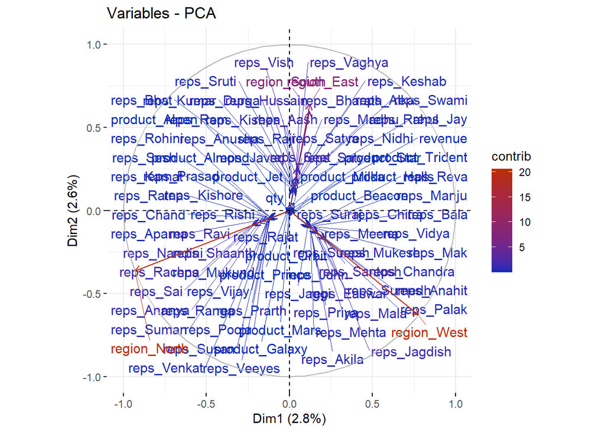

```r
#Visualizing PCA
fviz_pca_var(store_pca, col.var = "contrib", gradient.cols = c("#002bbb", "#bb2e00"), repel = TRUE)
```

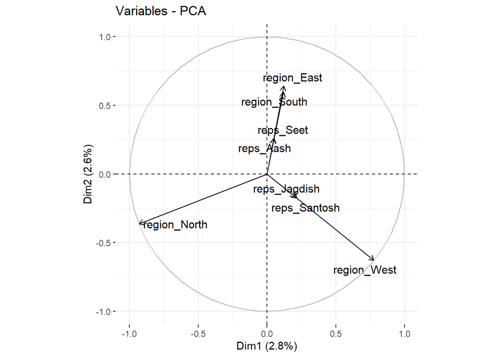

```r
#Creating a factor map for the top 10 variables with the highest contributions.
fviz_pca_var(store_pca, select.var = list(contrib = 8), repel = TRUE)
```

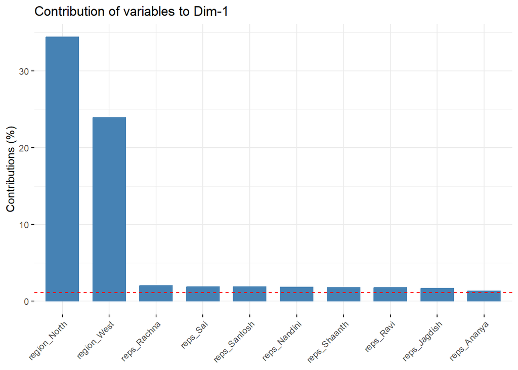

```r
#Barplotting the contributions of variables
fviz_contrib(store_pca, choice = "var", axes = 1, top = 10)
```

The red line corresponds to the expected percentage if the distributions were uniform.

## 6. K-means

The number of clusters (k) must be set before we start the algorithm. At first we can use several different values of k and examine the differences in the results.

```r
library(factoextra)
library(rattle)
library(cluster)
library(gclus)

set.seed(123)
k2 <- kmeans(datos_uns, centers = 2, nstart = 25)
k3 <- kmeans(datos_uns, centers = 3, nstart = 25)
k4 <- kmeans(datos_uns, centers = 4, nstart = 25)
k5 <- kmeans(datos_uns, centers = 5, nstart = 25)
k6 <- kmeans(datos_uns, centers = 6, nstart = 25)
```

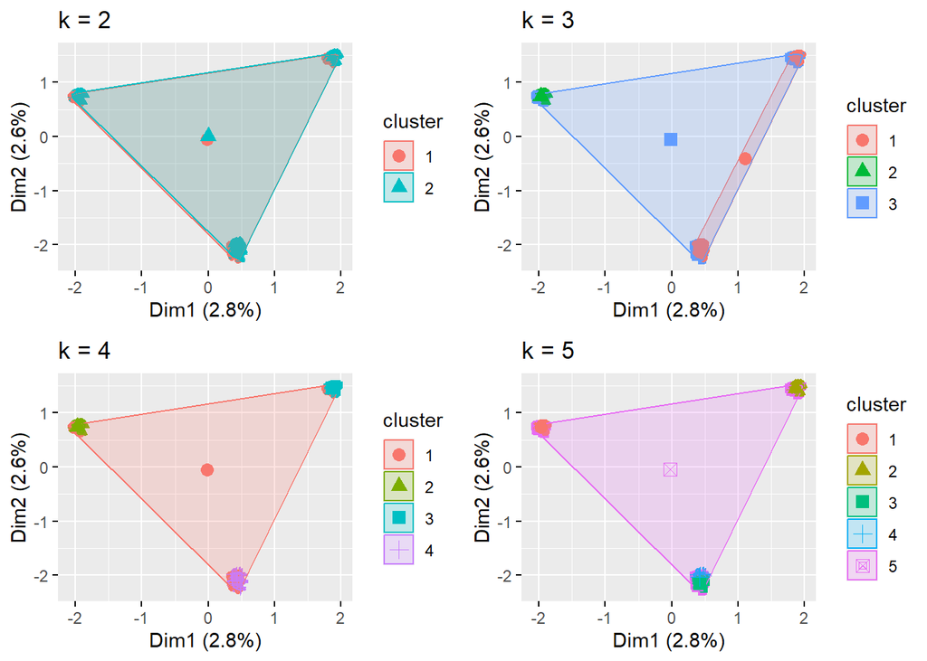

```r
# plots to compare
p1 <- fviz_cluster(k2, geom = "point", data = datos_uns) + ggtitle("k = 2")
p2 <- fviz_cluster(k3, geom = "point",  data = datos_uns) + ggtitle("k = 3")
p3 <- fviz_cluster(k4, geom = "point",  data = datos_uns) + ggtitle("k = 4")
p4 <- fviz_cluster(k5, geom = "point",  data = datos_uns) + ggtitle("k = 5")

library(gridExtra)
grid.arrange(p1, p2, p3, p4, nrow = 2)
```

```r
#Determining Optimal Clusters with elbow method
set.seed(123)
library(purrr)
```

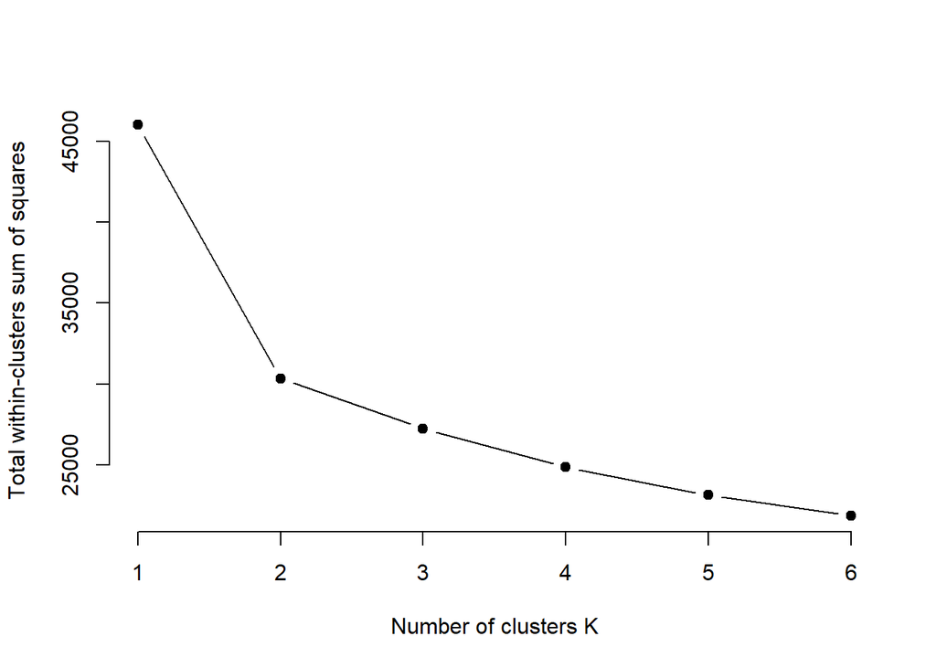

```r
# function to compute total within-cluster sum of square
wss <- function(k) {
  kmeans(datos_uns, k, nstart = 25 )$tot.withinss
}

# Compute and plot wss for k = 1 to k = 6
k.values <- 1:6

# extract wss for 2-6 clusters
wss_values <- map_dbl(k.values, wss)
#plot
plot(k.values, wss_values,
     type="b", pch = 19, frame = FALSE,
     xlab="Number of clusters K",
     ylab="Total within-clusters sum of squares")
```

According to the elbow method, the optimal K-value is 2.

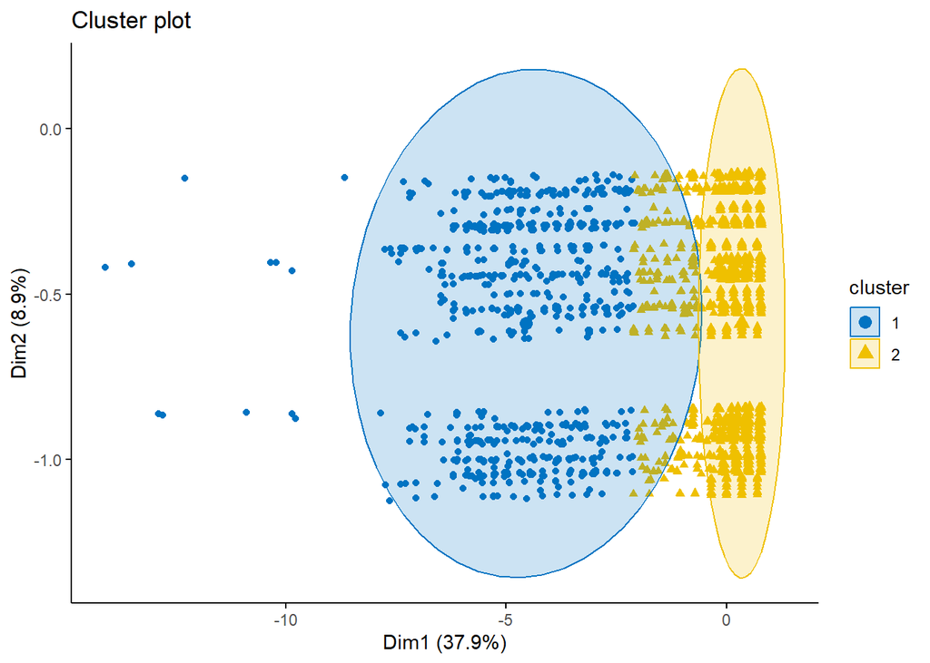

```r
##Building a k-means model with a k=2
set.seed(123)
km.res1 <- kmeans(datos_uns, 2, nstart = 25)

fviz_cluster(list(data = datos_uns, cluster = km.res1$cluster),
             ellipse.type = "norm", geom = "point", stand = FALSE,
             palette = "jco",ggtheme = theme_classic())
```

```r
#Extracting the vector of cluster assignment from the model
clust_store <- km.res1$cluster

#Building the segment_customers dataframe
segment_store <- mutate(datos_uns, cluster = clust_store)

#Calculating the mean for each category
count(segment_store, cluster)
```

```
##    cluster    n
## 1:       1  700
## 2:       2 9300
```

```r
#Adding the cluster variable to the original dataframe
datos <- datos %>% mutate(cluster = segment_store$cluster)

#Adding the cluster variable to the original dataframe
datos_uns <- datos_uns %>% mutate(cluster = segment_store$cluster)

#It’s possible to compute the mean of each variables by clusters using the original data:
datos %>%
  group_by(cluster) %>%
  summarise(mean_revenue = mean(revenue),
            mean_qty = mean(qty),
            tot_transactions = n())
```

```
## # A tibble: 2 × 4
##   cluster mean_revenue mean_qty tot_transactions
##     <int>        <dbl>    <dbl>            <int>
## 1       1        484.     17.9               700
## 2       2         60.9     2.30             9300
```

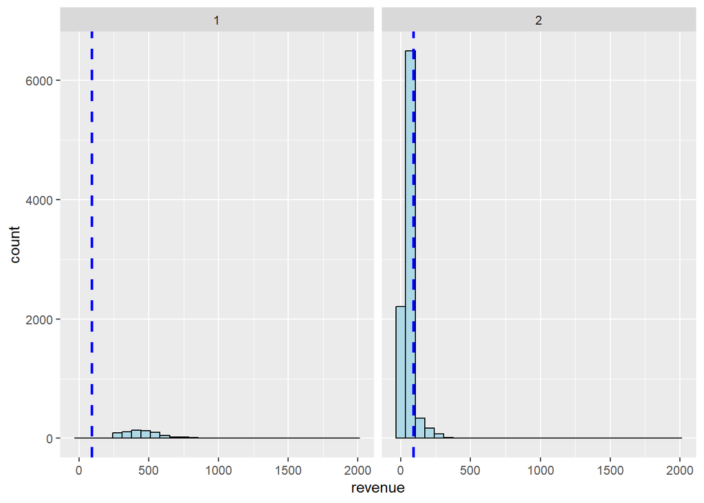

```r
#visualizing revenue
datos %>% ggplot(aes(revenue)) + geom_histogram(color = "black", fill = "lightblue") + facet_wrap(vars(cluster)) +  geom_vline(aes(xintercept=mean(revenue)),color="blue", linetype="dashed", size = 1)
```

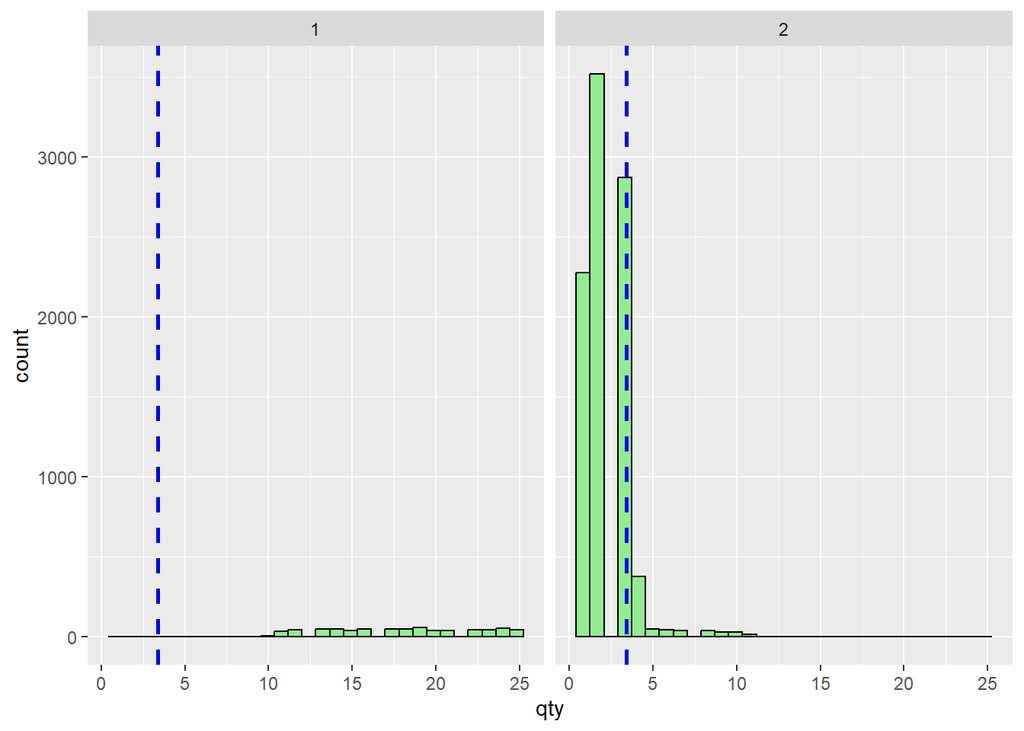

```r
#visualizing qty
datos %>% ggplot(aes(qty)) + geom_histogram(color = "black", fill = "lightgreen") + facet_wrap(vars(cluster)) +  geom_vline(aes(xintercept=mean(qty)),color="blue", linetype="dashed", size = 1)
```

## 7. Final conclusions

An unsupervised learning in R was perfomed with basic clustering (K-means) and dimesionality reduction (PCA) in order to get some insights from the data.

According with the results of the clustering analysis, we can compare the 2 clusters from the visuals above.

This dataset can be used to analyze various aspects of the store’s performance, including sales trends, regional differences, and the effectiveness of different products and representatives in generating revenue.

Other analysis clustering alternatives are *hierarchical clustering* or converting the numeric variables qty and revenue into categories and using *K-modes*.

## 8. References

Alboukadel Kassambara. Practical Guide to Cluster Analysis in R. Unsupervised Machine Learning. (2017).

Joaquín Amat Rodrigo. Análisis de Componentes Principales (Principal Component Analysis, PCA) y t-SNE (2017). Available at [link](https://www.cienciadedatos.net/documentos/35_principal_component_analysis)